# ABOUT THE DATASETS

# UPDATING THE MODEL BASED ON OPTIMAL THRESHOLD PROBABILITY

```python
new_predictions = np.where(probs>optimal_threshold, 1, 0)
```

```python
new_confusion_mat = metrics.confusion_matrix(y_test_encoded, new_predictions)
```

```python
confusion_LR = pd.DataFrame(new_confusion_mat, index=['Refused Term Deposit','Accepted Term Deposit'], columns=['Predicted Refusal','Predicted Acceptance'])
confusion_LR
```

|  | Predicted Refusal | Predicted Acceptance |
| --- | --- | --- |
| Refused Term Deposit | 922 | 130 |
| Accepted Term Deposit | 240 | 941 |

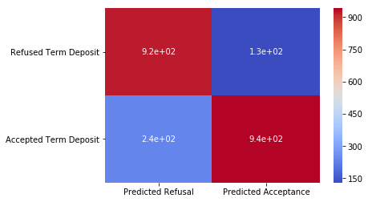

```python
# UPDATED VISUALIZATION OF CONFUSION MATRIX


_=sns.heatmap(confusion_LR, cmap='coolwarm', annot=True)
```

```python
# CALCULATE THE UPDATED ACCURACY SCORE & LOG LOSS METRICS

ACS_LR =accuracy_score(y_test, new_predictions)
print("Accuracy Score for LR: ", ACS_LR)

# CALCULATING UPDATED LOG LOSS

LL_LR = metrics.log_loss(y_test, new_predictions)
print("Log Loss for LR: ", LL_LR)
```

```
Accuracy Score for LR:  0.8343036274070756
Log Loss for LR:  5.722996513113694
```

# ---*---*---*---*---*---*---*---*---*---*---*---*---*---*---*---*---*---*---*---*---*---*---*---*---*---*---*---*---*---*---*---*---*---*---*---*

# GRIDSEARCHCV

```python
from sklearn.tree import DecisionTreeClassifier
from sklearn.model_selection import GridSearchCV
```

```python
param_grid = [{"max_depth":[3,4,5,None], "max_features":[2,3,4,5,None]}]
```

```python
gs = GridSearchCV(estimator=DecisionTreeClassifier(random_state=101),\
                 param_grid = param_grid,\
                 cv=10)
```

```python
gs.fit(X_train, y_train)
```

```
GridSearchCV(cv=10, error_score='raise-deprecating',
       estimator=DecisionTreeClassifier(class_weight=None, criterion='gini', max_depth=None,
            max_features=None, max_leaf_nodes=None,
            min_impurity_decrease=0.0, min_impurity_split=None,
            min_samples_leaf=1, min_samples_split=2,
            min_weight_fraction_leaf=0.0, presort=False, random_state=101,
            splitter='best'),
       fit_params=None, iid='warn', n_jobs=None,
       param_grid=[{'max_depth': [3, 4, 5, None], 'max_features': [2, 3, 4, 5, None]}],
       pre_dispatch='2*n_jobs', refit=True, return_train_score='warn',
       scoring=None, verbose=0)
```

```python
gs.cv_results_['params']
```

```
[{'max_depth': 3, 'max_features': 2},
 {'max_depth': 3, 'max_features': 3},
 {'max_depth': 3, 'max_features': 4},
 {'max_depth': 3, 'max_features': 5},
 {'max_depth': 3, 'max_features': None},
 {'max_depth': 4, 'max_features': 2},
 {'max_depth': 4, 'max_features': 3},
 {'max_depth': 4, 'max_features': 4},
 {'max_depth': 4, 'max_features': 5},
 {'max_depth': 4, 'max_features': None},
 {'max_depth': 5, 'max_features': 2},
 {'max_depth': 5, 'max_features': 3},
 {'max_depth': 5, 'max_features': 4},
 {'max_depth': 5, 'max_features': 5},
 {'max_depth': 5, 'max_features': None},
 {'max_depth': None, 'max_features': 2},
 {'max_depth': None, 'max_features': 3},
 {'max_depth': None, 'max_features': 4},
 {'max_depth': None, 'max_features': 5},
 {'max_depth': None, 'max_features': None}]
```

```python
# PRINT BEST HYPERPARAMETERS COMBINATION

gs.best_params_
```

```
{'max_depth': 5, 'max_features': None}
```

```python
gs.cv_results_['rank_test_score']
```

```
array([19, 20, 14, 13,  4, 18, 17,  7, 12,  3, 15, 16,  9, 11,  1, 10,  8,
        6,  5,  2])
```

```python
gs.best_estimator_
```

```
DecisionTreeClassifier(class_weight=None, criterion='gini', max_depth=5,
            max_features=None, max_leaf_nodes=None,
            min_impurity_decrease=0.0, min_impurity_split=None,
            min_samples_leaf=1, min_samples_split=2,
            min_weight_fraction_leaf=0.0, presort=False, random_state=101,
            splitter='best')
```

```python
gs_predictions = gs.predict(X_test)
```

# CONFUSION MATRIX BASED ON GRIDSEARCHCV

```python
confusion_mat_gs = confusion_matrix(y_test, gs_predictions)
confusion_GS = pd.DataFrame(confusion_mat_gs, index=['Refused Term Deposit','Accepted Term Deposit'], columns=['Predicted Refusal','Predicted Acceptance'])
```

```python
confusion_GS
```

|  | Predicted Refusal | Predicted Acceptance |
| --- | --- | --- |
| Refused Term Deposit | 941 | 111 |
| Accepted Term Deposit | 333 | 848 |

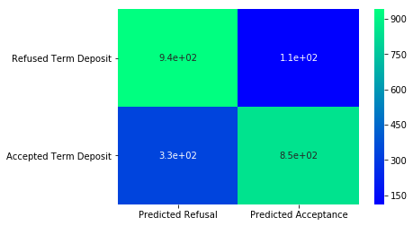

```python
_=sns.heatmap(confusion_GS, cmap="winter", annot=True)
```

```python
from sklearn.metrics import accuracy_score
```

```python
ACS_GS=accuracy_score(y_test,gs_predictions)
```

```python
print("GRIDSEARCHCV ACCURACY SCORE :",ACS_GS)
```

```
GRIDSEARCHCV ACCURACY SCORE : 0.8011643528884909
```

[output not shown]

# ---*---*---*---*---*---*---*---*---*---*---*---*---*---*---*---*---*---*---*---*---*---*---*---*---*---*---*---*---*---*---*---*---*---*---*---*

# DECISION TREE

```python
# SPLITTING THE DATASET INTO TRAIN-TEST

from sklearn.model_selection import train_test_split
X=df_1.drop(['depo_no'],axis=1)
y=df_1['depo_no']
```

```python
import sklearn.model_selection as model_selection

X_train,X_test,y_train,y_test = model_selection.train_test_split(X,y,test_size=0.2,random_state=101)
```

# FEATURE SCALING

```
Feature Scaling: We know our dataset is not yet a scaled value. Therefore, it would be beneficial to scale our data  To do so, we will use Scikit-Learn’s StandardScaler class:
```

```python
from sklearn.preprocessing import StandardScaler

sc = StandardScaler()
X_train = sc.fit_transform(X_train)
X_test = sc.transform(X_test)
```

```python
from sklearn.tree import DecisionTreeClassifier
```

```python
decision_tree = DecisionTreeClassifier(max_depth=5, max_features=None)
```

```python
decision_tree.fit(X_train, y_train)
```

```
DecisionTreeClassifier(class_weight=None, criterion='gini', max_depth=5,
            max_features=None, max_leaf_nodes=None,
            min_impurity_decrease=0.0, min_impurity_split=None,
            min_samples_leaf=1, min_samples_split=2,
            min_weight_fraction_leaf=0.0, presort=False, random_state=None,
            splitter='best')
```

```python
dt_predictions = decision_tree.predict(X_test)
```

```python
# CHECKING TOP 5 PREDICTIONS & ACTUAL VALUES

dt_predictions[:7]
```

```
array([0, 1, 0, 0, 0, 0, 0], dtype=uint8)
```

```python
y_test[:7]
```

```
8096    1
8180    1
1387    0
3047    0
4670    0
8895    1
9810    1
Name: depo_no, dtype: uint8
```

```python
# EVALUATING PREDICTION ACCURACY

from sklearn.metrics import accuracy_score, confusion_matrix
```

```python
ACS_DT =accuracy_score(y_test, dt_predictions)
print("Decision Tree Accuracy Score : ", ACS_DT)
```

```
Decision Tree Accuracy Score :  0.799820868786386
```

```python
# FINDING FEATURE IMPORTANCE

pd.Series(decision_tree.feature_importances_, index=X.columns).sort_values(ascending = False)
```

```
duration                  0.558635
pout_success              0.225850
contacted_unknown         0.113306
hloan_no                  0.055856
mon_oct                   0.017100
mon_mar                   0.014622
age                       0.003565
day                       0.002747
balance                   0.002404
marital_status_married    0.001978
work_student              0.001126
mon_may                   0.001113
previous                  0.000899
mon_apr                   0.000799
work_housemaid            0.000000
work_management           0.000000
work_unemployed           0.000000
work_retired              0.000000
work_self-employed        0.000000
work_services             0.000000
work_entrepreneur         0.000000
work_blue-collar          0.000000
campaign                  0.000000
work_technician           0.000000
pout_unknown              0.000000
work_unknown              0.000000
marital_status_single     0.000000
quali_tertiary            0.000000
quali_unknown             0.000000
defaulter_no              0.000000
ploan_no                  0.000000
contacted_telephone       0.000000
mon_aug                   0.000000
mon_dec                   0.000000
mon_feb                   0.000000
mon_jan                   0.000000
mon_jul                   0.000000
mon_jun                   0.000000
mon_sep                   0.000000
quali_secondary           0.000000
dtype: float64
```

# CONFUSION MATRIX BASED ON DECISION TREE

```python
import pandas as pd
import matplotlib.pyplot as plt
import seaborn as sns
%matplotlib inline
```

```python
decision_tree_confusion_mat = confusion_matrix(y_test, dt_predictions)
confusion_DT = pd.DataFrame(decision_tree_confusion_mat, index=['Refused Term Deposit','Accepted Term Deposit'], columns=['Predicted Refusal','Predicted Acceptance'])
```

```python
confusion_DT
```

|  | Predicted Refusal | Predicted Acceptance |
| --- | --- | --- |
| Refused Term Deposit | 939 | 113 |
| Accepted Term Deposit | 334 | 847 |

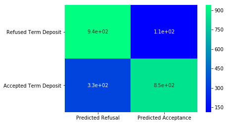

```python
_=sns.heatmap(confusion_DT, cmap="winter", annot=True)
```

```python
# VISUALIZE THE DECISION TREE OUTUT THROUGH GRAPHVIZ

from sklearn.tree import export_graphviz
import graphviz
```

```python
dot_data = export_graphviz(decision_tree, filled=True, rounded=True, feature_names=X.columns, out_file=None)
graphviz.Source(dot_data)
```

[figure not shown]

# ---*---*---*---*---*---*---*---*---*---*---*---*---*---*---*---*---*---*---*---*---*---*---*---*---*---*---*---*---*---*---*---*---*---*---*---*

# RANDOM FOREST CLASSIFIER

```python
from sklearn.ensemble import RandomForestClassifier
```

```python
rf_model = RandomForestClassifier(n_estimators=500, n_jobs=-1)
```

```python
rf_model.fit(X_train, y_train)
```

```
RandomForestClassifier(bootstrap=True, class_weight=None, criterion='gini',
            max_depth=None, max_features='auto', max_leaf_nodes=None,
            min_impurity_decrease=0.0, min_impurity_split=None,
            min_samples_leaf=1, min_samples_split=2,
            min_weight_fraction_leaf=0.0, n_estimators=500, n_jobs=-1,
            oob_score=False, random_state=None, verbose=0,
            warm_start=False)
```

```python
from sklearn.metrics import accuracy_score
```

```python
rf_predictions = rf_model.predict(X_test)
```

```python
ACS_RF=accuracy_score(y_test, rf_predictions)
print("RANDOM FOREST ACCURACY SCORE : ",ACS_RF)
```

```
RANDOM FOREST ACCURACY SCORE :  0.8652037617554859
```

# CONFUSION MATRIX BASED ON RANDOM FOREST

```python
confusion_mat_rf = confusion_matrix(y_test, rf_predictions)
confusion_RF = pd.DataFrame(confusion_mat_rf, index=['Refused Term Deposit','Accepted Term Deposit'], columns=['Predicted Refusal','Predicted Acceptance'])
confusion_RF
```

|  | Predicted Refusal | Predicted Acceptance |
| --- | --- | --- |
| Refused Term Deposit | 949 | 103 |
| Accepted Term Deposit | 198 | 983 |

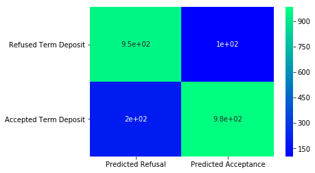

```python
_=sns.heatmap(confusion_RF, cmap="winter", annot=True)
```

```python
feature_list_RF = []
for Class, score in zip(X.columns, rf_model.feature_importances_):
    feature_list_RF.append((score, Class))
```

```python
sorted(feature_list_RF, reverse=True)
```

```
[(0.33931149026075724, 'duration'),
 (0.08578480586025762, 'balance'),
 (0.08087941135600736, 'age'),
 (0.07295592627861115, 'day'),
 (0.041190097591833987, 'pout_success'),
 (0.036751993513223495, 'campaign'),
 (0.03258715660478242, 'previous'),
 (0.03177505984940947, 'contacted_unknown'),
 (0.0278334291441535, 'hloan_no'),
 (0.015289078124105992, 'pout_unknown'),
 (0.014115903347709256, 'mon_mar'),
 (0.01405094965913274, 'mon_may'),
 (0.012952486993682557, 'mon_apr'),
 (0.012813734110942977, 'mon_oct'),
 (0.01177045652201588, 'ploan_no'),
 (0.011448785265651146, 'marital_status_married'),
 (0.011208477408995844, 'quali_secondary'),
 (0.01098873770718385, 'mon_jun'),
 (0.010750662005505, 'quali_tertiary'),
 (0.01070504889399688, 'mon_aug'),
 (0.009694076593617186, 'marital_status_single'),
 (0.009684383602511159, 'mon_feb'),
 (0.00965118382374974, 'work_blue-collar'),
 (0.009496490759462184, 'mon_jul'),
 (0.009167089297745585, 'work_technician'),
 (0.008993398711675767, 'work_management'),
 (0.007040775318011083, 'mon_sep'),
 (0.0064526108717180355, 'contacted_telephone'),
 (0.005896075187514913, 'work_services'),
 (0.005139249113342851, 'mon_jan'),
 (0.005111464924463559, 'work_student'),
 (0.004837722473679603, 'work_retired'),
 (0.004333951284083355, 'quali_unknown'),
 (0.004033227123039505, 'work_self-employed'),
 (0.003882753087874036, 'work_entrepreneur'),
 (0.0036842779741688408, 'work_unemployed'),
 (0.002905558947565188, 'work_housemaid'),
 (0.0023166441528107524, 'mon_dec'),
 (0.0015035964861553248, 'defaulter_no'),
 (0.0010117797688533312, 'work_unknown')]
```

# ---*---*---*---*---*---*---*---*---*---*---*---*---*---*---*---*---*---*---*---*---*---*---*---*---*---*---*---*---*---*---*---*---*---*---*---*

# ADABOOST ENSEMBLING MODE

```python
from sklearn.ensemble import AdaBoostClassifier
from sklearn.metrics import accuracy_score
import sklearn.metrics as metrics
```

```python
model = DecisionTreeClassifier(criterion='gini', max_depth=3)
```

```python
ada_boost_model = AdaBoostClassifier(base_estimator=model, learning_rate=1.0, n_estimators=500)
```

```python
boostmodel=ada_boost_model.fit(X_train, y_train)
```

```python
ada_boost_predictions=boostmodel.predict(X_test)
```

```python
ACS_ADB=accuracy_score(y_test,ada_boost_predictions)
```

```python
print("ADABOOST ACCURACY SCORE : ",ACS_ADB)
```

```
ADABOOST ACCURACY SCORE :  0.8150470219435737
```

```python
feature_list_ADB = []
for Class, score in zip(X.columns, ada_boost_model.feature_importances_):
    feature_list_ADB.append((score, Class))
```

```python
sorted(feature_list_ADB, reverse=True)
```

```
[(0.24358423909115662, 'balance'),
 (0.23641657056204574, 'duration'),
 (0.09890366984639981, 'day'),
 (0.09358851436946818, 'age'),
 (0.03893827435257379, 'campaign'),
 (0.03130288900942233, 'previous'),
 (0.014366722105719222, 'mon_may'),
 (0.014269939052972852, 'mon_apr'),
 (0.014264381122312745, 'mon_aug'),
 (0.012810930218030295, 'hloan_no'),
 (0.012294352785781093, 'mon_jul'),
 (0.012124122120079682, 'work_blue-collar'),
 (0.011030958455739794, 'contacted_unknown'),
 (0.010592892749774752, 'marital_status_single'),
 (0.010241500742476753, 'marital_status_married'),
 (0.009975909602490896, 'work_management'),
 (0.009961838867677713, 'ploan_no'),
 (0.009900468337676126, 'quali_tertiary'),
 (0.009637642996924467, 'mon_jun'),
 (0.008973936349724349, 'mon_feb'),
 (0.008783685332934835, 'work_technician'),
 (0.00828582006108544, 'work_services'),
 (0.008169764877269855, 'pout_success'),
 (0.007411536067059963, 'pout_unknown'),
 (0.006597842305690766, 'contacted_telephone'),
 (0.006489678029931604, 'mon_oct'),
 (0.006352562175472742, 'mon_mar'),
 (0.005681340621729568, 'quali_secondary'),
 (0.005623641205121898, 'mon_jan'),
 (0.005240815832029958, 'work_self-employed'),
 (0.004752378350623368, 'work_housemaid'),
 (0.003931458372699441, 'work_retired'),
 (0.0036234065449173847, 'mon_sep'),
 (0.0033768426555219094, 'work_entrepreneur'),
 (0.003058786609094482, 'work_unemployed'),
 (0.002811823600827733, 'work_student'),
 (0.002276822093061944, 'quali_unknown'),
 (0.0016202239964902701, 'mon_dec'),
 (0.0015169810083330933, 'defaulter_no'),
 (0.001214837521656394, 'work_unknown')]
```

# CONFUSION MATRIX BASED ON ADABOOST

```python
confusion_mat_ada_boost = confusion_matrix(y_test, ada_boost_predictions)
confusion_ADB = pd.DataFrame(confusion_mat_ada_boost, index=['Refused Term Deposit','Accepted Term Deposit'], columns=['Predicted Refusal','Predicted Acceptance'])
confusion_ADB
```

|  | Predicted Refusal | Predicted Acceptance |
| --- | --- | --- |
| Refused Term Deposit | 843 | 209 |
| Accepted Term Deposit | 204 | 977 |

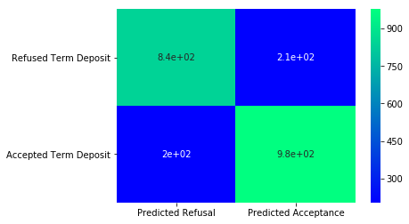

```python
_=sns.heatmap(confusion_ADB, cmap="winter", annot=True)
```

# ---*---*---*---*---*---*---*---*---*---*---*---*---*---*---*---*---*---*---*---*---*---*---*---*---*---*---*---*---*---*---*---*---*---*---*---*

# VOTING CLASSFIER

```python
# IMPORTING NECESSARY LIBRARIES

from sklearn.linear_model import LogisticRegression
from sklearn.model_selection import GridSearchCV
from sklearn.tree import DecisionTreeClassifier
from sklearn.ensemble import RandomForestClassifier
from sklearn.ensemble import VotingClassifier
```

```python
v_log_model = LogisticRegression()
v_gs_model = GridSearchCV(estimator=DecisionTreeClassifier(random_state=101), param_grid = param_grid, cv=10)
v_dtree_model = DecisionTreeClassifier()
v_rf_model = RandomForestClassifier()
```

```python
ensemble = VotingClassifier(estimators=[('V_LR', v_log_model), ('V_GS',v_gs_model),('V_DT', v_dtree_model),('V_RF', v_rf_model)], voting='hard')
```

```python
ensemble.fit(X_train, y_train)
```

```
VotingClassifier(estimators=[('V_LR', LogisticRegression(C=1.0, class_weight=None, dual=False, fit_intercept=True,
          intercept_scaling=1, max_iter=100, multi_class='warn',
          n_jobs=None, penalty='l2', random_state=None, solver='warn',
          tol=0.0001, verbose=0, warm_start=False)), ('V_GS', Grid...obs=None,
            oob_score=False, random_state=None, verbose=0,
            warm_start=False))],
         flatten_transform=None, n_jobs=None, voting='hard', weights=None)
```

```python
from sklearn.metrics import accuracy_score
```

```python
for model in (v_log_model, v_gs_model, v_dtree_model, v_rf_model, ensemble):
    model.fit(X_train, y_train)
    v_predictions = model.predict(X_test)
    print(model.__class__.__name__, accuracy_score(y_test, v_predictions))
```

```
LogisticRegression 0.8320644872369011
GridSearchCV 0.8011643528884909
DecisionTreeClassifier 0.7904164800716524
```

```
RandomForestClassifier 0.8454993282579489
```

```
VotingClassifier 0.8472906403940886
```

```python
ACS_V=accuracy_score(y_test, v_predictions)
print(ACS_V)
```

```
0.8472906403940886
```

# CONFUSION MATRIX BASED ON VOTING CLASSIFIER

```python
confusion_mat_V= confusion_matrix(y_test, v_predictions)
confusion_V = pd.DataFrame(confusion_mat_V, index=['Refused Term Deposit','Accepted Term Deposit'], columns=['Predicted Refusal','Predicted Acceptance'])
confusion_V
```

|  | Predicted Refusal | Predicted Acceptance |
| --- | --- | --- |
| Refused Term Deposit | 974 | 78 |
| Accepted Term Deposit | 263 | 918 |

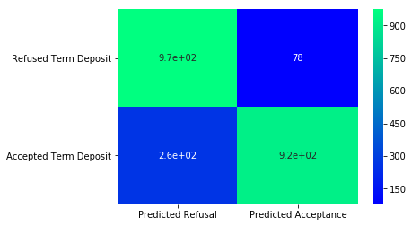

```python
_=sns.heatmap(confusion_V, cmap="winter", annot=True)
```

# ---*---*---*---*---*---*---*---*---*---*---*---*---*---*---*---*---*---*---*---*---*---*---*---*---*---*---*---*---*---*---*---*---*---*---*---*

# COMPARISON OF ML MODEL BASED CONFUSION MATRIX

```python
print('LR',confusion_LR,"\n")   # Decision Tree
print('GS',confusion_GS,"\n")   # GridSearchCV
print('DT',confusion_DT,"\n")   # Decision Tree
print('RF',confusion_RF,"\n")   # Random Forest
print('ADB',confusion_ADB,"\n") # Ada Boost
print('VC',confusion_V,"\n")    # Voting Classifier
```

```
LR                        Predicted Refusal  Predicted Acceptance
Refused Term Deposit                 922                   130
Accepted Term Deposit                240                   941

GS                        Predicted Refusal  Predicted Acceptance
Refused Term Deposit                 941                   111
Accepted Term Deposit                333                   848

DT                        Predicted Refusal  Predicted Acceptance
Refused Term Deposit                 939                   113
Accepted Term Deposit                334                   847

RF                        Predicted Refusal  Predicted Acceptance
Refused Term Deposit                 949                   103
Accepted Term Deposit                198                   983

ADB                        Predicted Refusal  Predicted Acceptance
Refused Term Deposit                 843                   209
Accepted Term Deposit                204                   977

VC                        Predicted Refusal  Predicted Acceptance
Refused Term Deposit                 974                    78
Accepted Term Deposit                263                   918
```

Based on Confusion Matrix we can conclude that the Random Forest model was the best model as it is having the least number of misclassified observations from test set.

# COMPARISON OF ML MODEL BASED ACCURACY SCORE VALUES

```python
ACS_FINAL= pd.DataFrame(columns=['Model_Name', 'Accuracy_Score'])
```

```python
ACS_FINAL['Accuracy_Score']=[ACS_LR, ACS_GS, ACS_DT, ACS_RF, ACS_ADB, ACS_V]
```

```python
ACS_FINAL['Model_Name']=['LogisticRegression', 'GridSearchCV', 'Decision_Tree', 'RandomForest', 'Ada Boost', \
                         'Voting CLassifier']
```

```python
def highlight_max(s):
    is_max = s == s.max()
    return ['background-color: yellow' if v else '' for v in is_max]
```

```python
ACS_FINAL[['Model_Name', 'Accuracy_Score']].sort_values('Accuracy_Score', ascending=False)\
.style.apply(highlight_max, subset=['Accuracy_Score'])
```

|  | Model_Name | Accuracy_Score |
| --- | --- | --- |
| 3 | RandomForest | 0.865204 |
| 5 | Voting CLassifier | 0.847291 |
| 0 | LogisticRegression | 0.834304 |
| 4 | Ada Boost | 0.815047 |
| 1 | GridSearchCV | 0.801164 |
| 2 | Decision_Tree | 0.799821 |

# ---*---*---*---*---*---*---*---*---*---*---*---*---*---*---*---*---*---*---*---*---*---*---*---*---*---*---*---*---*---*---*---*---*---*---*---*

# CONCLUSION 1: ML MODEL SELECTION

In order to make any actionable recommendations, we must look upon the feature importances based on our selected model i.e. Random Forest model.

```python
# RECALLING THE FEATURE IMPORTANCE LIST

sorted(feature_list_RF, reverse=True)
```

```
[(0.33931149026075724, 'duration'),
 (0.08578480586025762, 'balance'),
 (0.08087941135600736, 'age'),
 (0.07295592627861115, 'day'),
 (0.041190097591833987, 'pout_success'),
 (0.036751993513223495, 'campaign'),
 (0.03258715660478242, 'previous'),
 (0.03177505984940947, 'contacted_unknown'),
 (0.0278334291441535, 'hloan_no'),
 (0.015289078124105992, 'pout_unknown'),
 (0.014115903347709256, 'mon_mar'),
 (0.01405094965913274, 'mon_may'),
 (0.012952486993682557, 'mon_apr'),
 (0.012813734110942977, 'mon_oct'),
 (0.01177045652201588, 'ploan_no'),
 (0.011448785265651146, 'marital_status_married'),
 (0.011208477408995844, 'quali_secondary'),
 (0.01098873770718385, 'mon_jun'),
 (0.010750662005505, 'quali_tertiary'),
 (0.01070504889399688, 'mon_aug'),
 (0.009694076593617186, 'marital_status_single'),
 (0.009684383602511159, 'mon_feb'),
 (0.00965118382374974, 'work_blue-collar'),
 (0.009496490759462184, 'mon_jul'),
 (0.009167089297745585, 'work_technician'),
 (0.008993398711675767, 'work_management'),
 (0.007040775318011083, 'mon_sep'),
 (0.0064526108717180355, 'contacted_telephone'),
 (0.005896075187514913, 'work_services'),
 (0.005139249113342851, 'mon_jan'),
 (0.005111464924463559, 'work_student'),
 (0.004837722473679603, 'work_retired'),
 (0.004333951284083355, 'quali_unknown'),
 (0.004033227123039505, 'work_self-employed'),
 (0.003882753087874036, 'work_entrepreneur'),
 (0.0036842779741688408, 'work_unemployed'),
 (0.002905558947565188, 'work_housemaid'),
 (0.0023166441528107524, 'mon_dec'),
 (0.0015035964861553248, 'defaulter_no'),
 (0.0010117797688533312, 'work_unknown')]
```

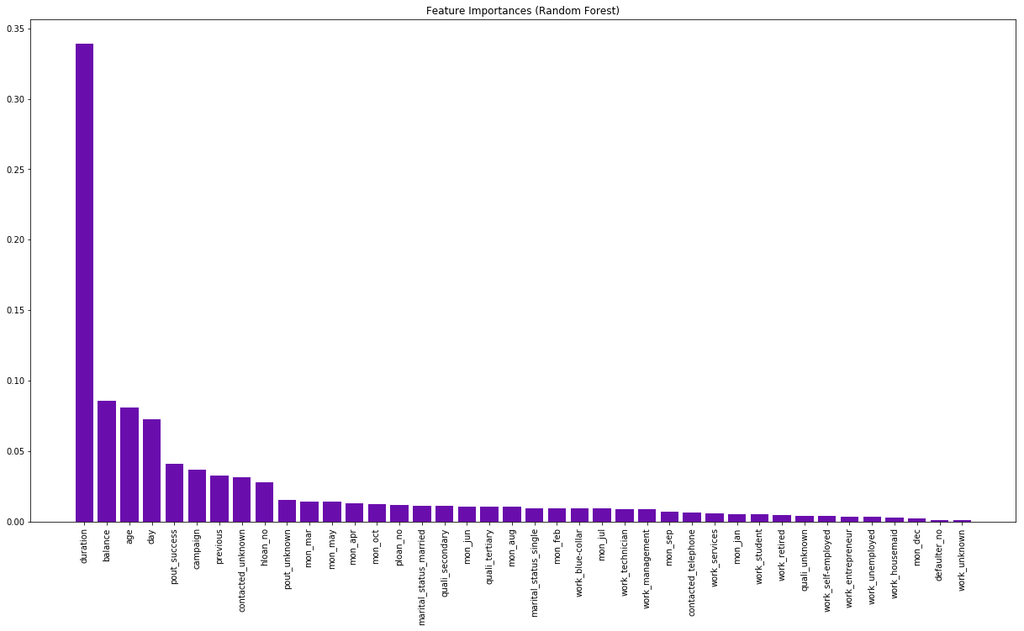

```python
# PLOTTING FEATURES IMPORTANCES

plt.figure(figsize=(21,11))

FI_RF = pd.DataFrame(sorted(zip(X.columns, rf_model.feature_importances_), \
                            key=lambda x: x[1], reverse= True), columns = ["Features", "Score"])

index = np.arange(len(FI_RF))
plt.bar(index, FI_RF['Score'], color = '#6a0dad')
plt.xticks(index, FI_RF['Features'], rotation=90)
plt.title('Feature Importances (Random Forest)')

plt.show()
```

As we can see from the above shown barplot representing the feature importances. It is evident that the top 4 most important features are:

[output not shown]

# CONCLUSION 2: BUSINESS SOLUTION

Based on above mentioned features we can conclude the following:

[output not shown]

Now let's try to be more specific with our suggestions

```python
# CREATING A COPY OF THE CLEANED DATA (DF_1)

df_2 = df_1.copy()
```

Q1) The duration of time a customer should be contacted for?

```python
# CREATING A NEW COLUMN (CONTACT_DURATION)

df_2['contact_duration'] = pd.qcut(df_2['duration'], q=10, labels=False, duplicates = 'drop')
```

```python
#GROUPING THE 'CONTACT_DURATION' AND FINDING AVERAGE CONTACT DURATION
mean_contact_duration = df_2.groupby(['contact_duration'])['depo_no'].mean()
```

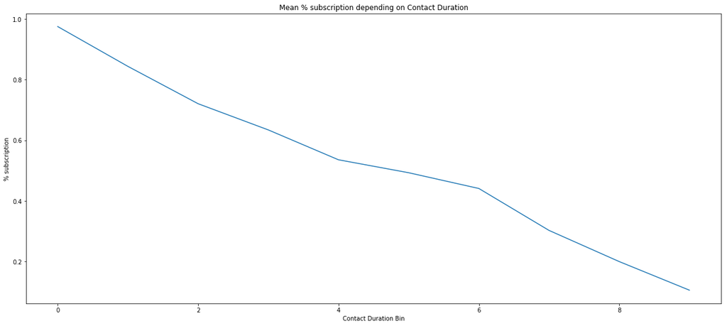

```python
# PLOTTING THE MEAN % SUBSCRIPTION VS CONTACT DURATION
plt.figure(figsize=(21,9))
plt.plot(mean_contact_duration.index, mean_contact_duration.values)
plt.title('Mean % subscription depending on Contact Duration')
plt.xlabel('Contact Duration Bin')
plt.ylabel('% subscription')
plt.show()
```

```python
df_2[df_2['contact_duration'] == 4]['duration'].max()
```

```
255
```

```python
df_2[df_2['contact_duration'] == 6]['duration'].min()
```

```
324
```

A1) From the above graph we can say that the average duration of time (in seconds) a customer should be contacted for must lie between 255 to 324 seconds(4-6 mins). Hence the campaign should have a sales pitch which does not exceed these limits.

Q2) The account balance of a customer who should be contacted?

```python
# CREATING A NEW COLUMN (CUST_BAL)


df_2['cust_bal'] = pd.qcut(df_2['balance'], q=50, labels=False, duplicates = 'drop')
```

```python
#GROUPING THE 'CUST_BAL' AND FINDING AVERAGE CUSTOMER BALANCE

mean_cust_bal = df_2.groupby(['cust_bal'])['depo_no'].mean()
```

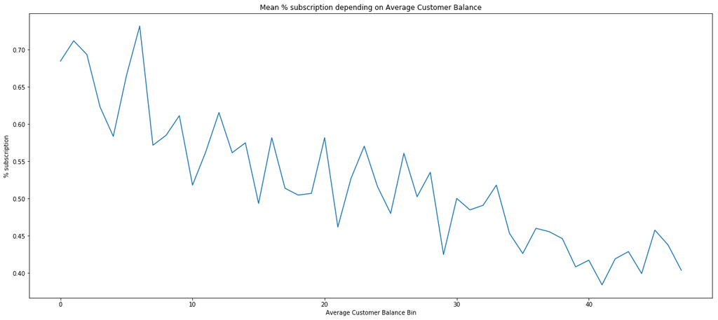

```python
# PLOTTING THE MEAN % SUBSCRIPTION VS AVERAGE CUSTOMER BALANCE
plt.figure(figsize=(21,9))
plt.plot(mean_cust_bal.index, mean_cust_bal.values)
plt.title('Mean % subscription depending on Average Customer Balance')
plt.xlabel('Average Customer Balance Bin')
plt.ylabel('% subscription')
plt.show()
```

```python
df_2[df_2['cust_bal'] == 28]['balance'].max()
```

```
935
```

A2) From the above graph we can say that the customers having account balance of $935 & above should be the primary focus of the marketing campaign. These customers are more likely to go for a term deposit.

Q3) The age range of a customer who should be contacted?

```python
# CREATING A NEW COLUMN (CUST_AGE)


df_2['cust_age'] = pd.qcut(df_2['age'], q=10, labels=False, duplicates = 'drop')
```

```python
#GROUPING THE 'CUST_BAL' AND FINDING AVERAGE CUSTOMER BALANCE

mean_cust_age = df_2.groupby(['cust_age'])['depo_no'].mean()
```

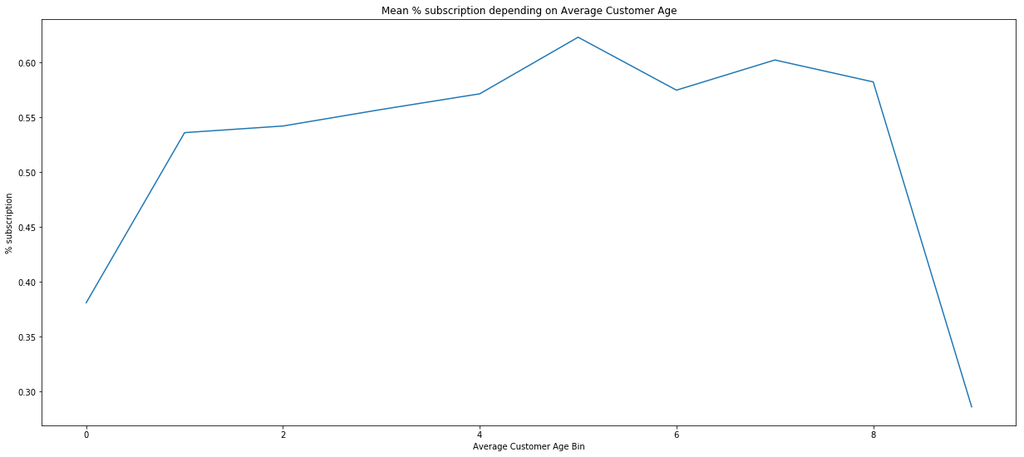

```python
# PLOTTING THE MEAN % SUBSCRIPTION VS AVERAGE CUSTOMER BALANCE
plt.figure(figsize=(21,9))
plt.plot(mean_cust_age.index, mean_cust_age.values)
plt.title('Mean % subscription depending on Average Customer Age')
plt.xlabel('Average Customer Age Bin')
plt.ylabel('% subscription')
plt.show()
```

```python
df_2[df_2['cust_age'] == 1]['age'].max()
```

```
31
```

```python
df_2[df_2['cust_age'] == 8]['age'].min()
```

```
53
```

A3) From the above graph we can say that the average age of a customer to be approached for should be less than 31 or higher than 53. These customers are more likely to go for a term deposit.

The marketing campaign should avoid focusing on age groups between 31 & 53.

Q4) The day of the month a customer should be approached?

```python
# CREATING A NEW COLUMN (APPROACH DAY)


df_2['app_day'] = pd.qcut(df_2['day'], q=4, labels=False, duplicates = 'drop')
```

```python
#GROUPING THE 'CUST_BAL' AND FINDING AVERAGE CUSTOMER BALANCE

mean_app_day = df_2.groupby(['app_day'])['depo_no'].mean()
```

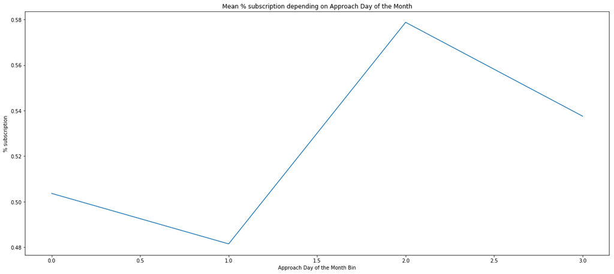

```python
# PLOTTING THE MEAN % SUBSCRIPTION VS AVERAGE CUSTOMER BALANCE
plt.figure(figsize=(21,9))
plt.plot(mean_app_day.index, mean_app_day.values)
plt.title('Mean % subscription depending on Approach Day of the Month')
plt.xlabel('Approach Day of the Month Bin')
plt.ylabel('% subscription')
plt.show()
```

```python
df_2[df_2['app_day'] == 0]['day'].max()
```

```
8
```

```python
df_2[df_2['app_day'] == 3]['day'].min()
```

```
23
```

# ---*---*---*---*---*---*---*---*---*---*---*---*---*---*---*---*---*---*---*---*---*---*---*---*---*---*---*---*---*---*---*---*---*---*---*---*

# FINAL SUMMARY

Key outcomes of the analysis are the recommendations for future marketing campaigns:

[output not shown]